**BACKGROUND**

It is important that credit card companies are able to recognize fraudulent credit card transactions so that customers are not charged for items they have not purchased.

**CONTENTS**

The data set includes credit card transactions carried out by European cardholders in September 2013. This data set shows transactions that occurred within two days, where we have **492 frauds out of 284,807 transactions.** It is very unbalanced, with the positive class (fraud) accounting for 0.17% of all transactions.

|  | Frequency | Ratio |
| --- | --- | --- |
| Fraud | 492 | 0.17% |
| No fraud | 284,315 | 99.83% |

Unfortunately, due to confidentiality issues, we cannot provide the original features and more basic information about the data. The V1, V2, …, V28 functionalities are the main components obtained with PCA. The only features that have not been transformed with PCA are ‘Time’ and ‘Amount’.

| Variables | Description |
| --- | --- |
| V1,…,V28 | Main components (anonymous) |
| Time | Seconds between each transaction and the first transaction in the data set |
| Amount | Amount of the transaction |
| Class | Response variable (1 in case of fraud 0 otherwise) |

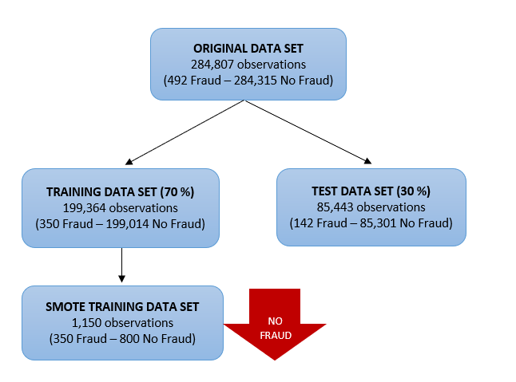

**GOALS**

Identify fraudulent credit card transactions. Given the imbalance ratio of the response variable (Class), **we will measure the accuracy of our model using several selection indicators in order to choose the most appropriate model.**

[figure not shown]